# Logistic Regression and Random Forest using R on Kaggle’s Titanic dataset

## 17. Evaluate Model Performance - ROC-AUC curve

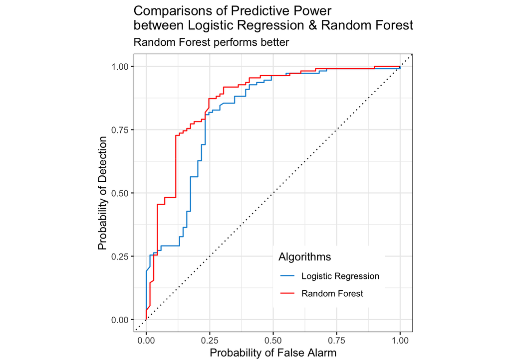

```r
comparing_predictions %>%
  group_by(algo) %>%
  roc_curve(Survived, .pred_0) %>%
  autoplot() +
  ggthemes::scale_color_fivethirtyeight(name = "Algorithms") +
  theme(legend.position = c(.70, .20)
  ) +
  labs(title = "Comparisons of Predictive Power\nbetween Logistic Regression & Random Forest",
       subtitle = "Random Forest performs better",
       x = "Probability of False Alarm",
       y = "Probability of Detection")
```

Clearly, Random Forest performs better than Logistic Regression here.

## 18. Variable Importance

As the random forest model is clearly more superior, we will utilize this model for the next plot on variable importance.

We will first save all the predictions into the `finalized model`. This is our ultimate model.

```r
finalized_model <- finalized_workflow_RF_a %>% fit(titanic2)
```

We will then create a summary of the model.

```r
summary_of_finalized_model <- extract_fit_parsnip(finalized_model)$fit
```

We then create the dataframe `variable_importance` to store the importance of the feature.

```r
variable_importance <- data.frame(importance = summary_of_finalized_model$variable.importance) %>%
  rownames_to_column("feature") %>%
  as_tibble() %>%
  mutate(feature = factor(feature))
```

We will then visualize the comparison of the features that are more significant.

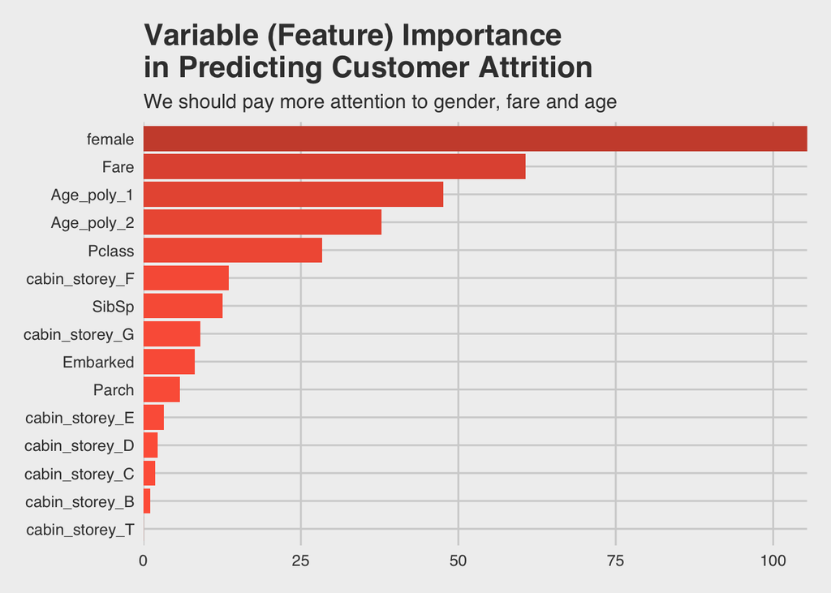

```r
variable_importance %>%
  ggplot(aes(x = importance,
             y = reorder(feature, importance)
  )
  ) +
  geom_col(aes(fill = importance),
           show.legend = F) +
  scale_fill_gradient(low = "tomato1",
                      high = "tomato3") +
  scale_x_continuous(expand = c(0, 0)
  ) +
  ggthemes::theme_fivethirtyeight() +
  labs(title = "Variable (Feature) Importance\nin Predicting Customer Attrition",
       subtitle = "We should pay more attention to gender, fare and age")
```

## 19. Predict on test dataset

Lastly, we shall predict using the `test` dataset given by Kaggle. We shall first modify the dataset do that the types are similar.

```r
titanic_test2 <- titanic_test %>%
  mutate(female = ifelse(Sex == "male", 0, 1),
         Embarked = as.factor(Embarked),
         Embarked = as.numeric(Embarked),# 3=S, 2=Q, 1=C
         cabin_storey = str_extract(Cabin, pattern="^[:alpha:]"),
         cabin_storey = as.factor(cabin_storey),
         row_id = as.numeric(row_number())) %>%
  select(-Name, -Sex, -Ticket, -PassengerId, -Cabin)
```

We then predict on test data.

```r
predictions <- titanic_test %>%
  select(PassengerId) %>%
  mutate(Survived = finalized_model %>% predict(titanic_test2),
         Survived = Survived$.pred_class)
```

That’s all! Results were not that great for now, hence my aim is to continue to refine the model.